# Utils

Components that are not part of the core functionality of the library but in general make its use better

## Setup

```python
c = genai.client.Client(api_key=os.environ.get("GEMINI_API_KEY"))
```

```python
r = c.models.generate_content(model='gemini-2.0-flash', contents="Hi Gemini!")
print(r.text)
```

```
Hi there! How can I help you today?
```

```python
mr = c.models.generate_images(
    model = 'imagen-3.0-generate-002',
    prompt = "Turtles in space",
    config = {"number_of_images": 2}
)
```

```python
mmr = c.models.generate_content(model='gemini-2.0-flash-exp',
                                contents="Generate an watercolor picture of a peaceful pond and write a Haiku about it",
                               config={"response_modalities": ["TEXT", "IMAGE"]})
```

## Models and their functionalities

**Exported source**

```python
all_model_types = {
    "gemini-2.0-flash": "llm-vertex#gemini-2.0-flash",
    "gemini-2.0-flash-lite": "llm#gemini-2.0-flash-lite",
    "gemini-2.5-pro-preview-03-25": "llm-thinking#gemini-2.5-pro",
    "gemini-2.5-pro-exp-03-25": "llm-thinking#gemini-2.5-pro",
    "gemini-2.5-flash-preview-04-17": "llm-thinking#gemini-2.5-flash",
    "gemini-2.0-flash-exp": "llm-imagen#gemini-2.0-flash",
    "gemini-2.0-flash-exp-image-generation": "llm-imagen#gemini-2.0-flash",
    "gemini-2.0-flash-001": "llm-vertex#gemini-2.0-flash",
    "gemini-2.0-pro-exp-02-05": "llm#gemini-2.0-pro",
    "gemini-1.5-flash": "llm-vertex#gemini-1.5-flash",
    "gemini-1.5-pro": "llm-vertex#gemini-1.5-pro",
    "gemini-1.5-pro-002": "llm-vertex#gemini-1.5-pro",
    "gemini-1.5-flash-8b": "llm#gemini-1.5-flash-8b",
    "gemini-2.0-flash-thinking-exp-01-21": "llm-thinking#gemini-2.0-flash-thinking",
    "imagen-3.0-generate-002": "imagen#imagen-3.0"
}

thinking_models = [m for m in all_model_types if "thinking" in all_model_types[m]]

imagen_models = [m for m in all_model_types if "imagen" in all_model_types[m]]

vertex_models = [m for m in all_model_types if "vertex" in all_model_types[m]]

models = [m for m in all_model_types if "llm" in all_model_types[m]]

models
```

```
['gemini-2.0-flash',
 'gemini-2.0-flash-lite',
 'gemini-2.5-pro-preview-03-25',
 'gemini-2.5-pro-exp-03-25',
 'gemini-2.5-flash-preview-04-17',
 'gemini-2.0-flash-exp',
 'gemini-2.0-flash-exp-image-generation',
 'gemini-2.0-flash-001',
 'gemini-2.0-pro-exp-02-05',
 'gemini-1.5-flash',
 'gemini-1.5-pro',
 'gemini-1.5-pro-002',
 'gemini-1.5-flash-8b',
 'gemini-2.0-flash-thinking-exp-01-21']
```

With the impressive speed they are shipping lately, it’s not easy to keep track of all the capabilities and model names and version that can be accessed with Gemini. The `all_model_types` is a curated list of possibilities that can be used. All the other models are still accessible, but they are mostly legacy models.

## Token Usage

```python
r.usage_metadata.model_fields_set
```

```
{'candidates_token_count', 'prompt_token_count', 'total_token_count'}
```

[source](https://github.com/mikonapoli/gaspare/blob/main/gaspare/utils.py#L48)

### usage

> ```
>  usage (inp=0, out=0, cached=0)
> ```

*A quicker and simpler constructor for the Usage Metadata model*

|  | **Type** | **Default** | **Details** |
| --- | --- | --- | --- |
| inp | int | 0 | Number of input tokens (excluding cached) |
| out | int | 0 | Number of output tokens |
| cached | int | 0 | Number of cached tokens |

**Exported source**

```python
def usage(inp=0,     # Number of input tokens (excluding cached)
          out=0,     # Number of output tokens
          cached=0): # Number of cached tokens
    """A quicker and simpler constructor for the Usage Metadata model"""
    return types.GenerateContentResponseUsageMetadata(cached_content_token_count=cached,
                                                      candidates_token_count=out,
                                                      prompt_token_count=inp + cached,
                                                      total_token_count=inp + out + cached)
```

Unusually, `prompt_token_count` includes both cached and uncached prompt tokens.

```python
usage(0, 32, 12)
```

```
GenerateContentResponseUsageMetadata(cached_content_token_count=12, candidates_token_count=32, prompt_token_count=12, total_token_count=44)
```

As usual, constructor for models are very verbose, so we build a simpler version.

### GenerateContentResponseUsageMetadata.total

> ```
>  GenerateContentResponseUsageMetadata.total ()
> ```

**Exported source**

```python
@patch(as_prop=True)
def cached(self: types.GenerateContentResponseUsageMetadata):
    return self.cached_content_token_count or 0

@patch(as_prop=True)
def inp(self: types.GenerateContentResponseUsageMetadata):
    return (self.prompt_token_count - self.cached) or 0

@patch(as_prop=True)
def out(self: types.GenerateContentResponseUsageMetadata):
    return self.candidates_token_count or 0

@patch(as_prop=True)
def total(self: types.GenerateContentResponseUsageMetadata):
    return self.total_token_count or self.prompt_token_count + self.candidates_token_count
```

### GenerateContentResponseUsageMetadata.out

> ```
>  GenerateContentResponseUsageMetadata.out ()
> ```

### GenerateContentResponseUsageMetadata.inp

> ```
>  GenerateContentResponseUsageMetadata.inp ()
> ```

### GenerateContentResponseUsageMetadata.cached

> ```
>  GenerateContentResponseUsageMetadata.cached ()
> ```

```python
u = usage(1, 2, 3)
u.inp, u.out, u.cached, u.total
```

```
(1, 2, 3, 6)
```

We patch a few properties to make dealing with the usage object a bit less verbose.

### GenerateContentResponseUsageMetadata.__repr__

> ```
>  GenerateContentResponseUsageMetadata.__repr__ ()
> ```

**Exported source**

```python
@patch
def __repr__(self: types.GenerateContentResponseUsageMetadata):
    return f"Cached: {self.cached}; In: {self.inp}; Out: {self.out}; Total: {self.total}"

@patch
def _repr_markdown_(self: types.GenerateContentResponseUsageMetadata):
    return self.__repr__()
```

```python
u
```

Cached: 3; In: 1; Out: 2; Total: 6

Finally, we make the string and markdown representation a bit more readable and coherent with the ones in claudette.

### GenerateContentResponseUsageMetadata.__add__

> ```
>  GenerateContentResponseUsageMetadata.__add__ (other)
> ```

**Exported source**

```python
@patch
def __add__(self: types.GenerateContentResponseUsageMetadata, other):
    cached = getattr(self, "cached", 0) + getattr(other, "cached", 0)
    return usage(self.inp + other.inp, self.out + other.out, cached)
```

```python
usage(5, 1) + usage(32, 32, 32)
```

Cached: 32; In: 37; Out: 33; Total: 102

## Pricings

[source](https://github.com/mikonapoli/gaspare/blob/main/gaspare/utils.py#L112)

### get_pricing

> ```
>  get_pricing (model, prompt_tokens, thinking_mode=True)
> ```

**Exported source**

```python
# $/1M input (non cached) tokens, $/1M output tokens, $/1M cached input tokens,

pricings = {
    'gemini-2.5-pro_short': [1.25, 10., 0.3125],
    'gemini-2.5-pro_long': [2.5, 15., 0.625],
    'gemini-2.5-flash': [0.15, .6, 0.0375], # No cache for this yet
    'gemini-2.5-flash_thinking': [0.15, 3.5, 0.0375],
    'gemini-2.0-flash': [0.1, 0.4, 0.025],
    'gemini-2.0-flash-lite': [0.075, 0.3, 0.01875],
    'gemini-1.5-flash_short': [0.075, 0.3, 0.01875],
    'gemini-1.5-flash_long': [0.15, 0.6, 0.0375],
    'gemini-1.5-flash-8b_short': [0.0375, 0.15, 0.01],
    'gemini-1.5-flash-8b_long': [0.075, 0.3, 0.02],
    'gemini-1.5-pro_short': [1.25, 5., 0.3125],
    'gemini-1.5-pro_long': [2.5, 10., 0.625],
 }


audio_token_pricings = {
    'gemini-2.0-flash': [0.7, 0.4, 0.175],
}

def get_pricing(model, prompt_tokens, thinking_mode=True):
    if "exp" in model: return [0, 0, 0]
    limit = 200_000 if '2.5-pro' in model else 128_000
    suff = "_long" if prompt_tokens > limit else "_short"
    m = all_model_types.get(model, "#").split("#")[-1]
    m += suff if "1.5" in m or "2.5-pro" in m else ""
    m += "_thinking" if "2.5-flash" in m and thinking_mode else ""
    return pricings.get(m, [0, 0, 0])
```

The pricing of Gemini model queries is quite byzantine, with the price of a query on Gemini 1.5 dependent on the prompt length, while for Gemini 2.0 models it depends on the input type, and Gemini 2.5 depending on *different* prompt lengths (except for 2.5 flash, whose pricing depends on whether thinking is enabled or not)…

A few things to notice:

- The differential pricings for audio tokens for Gemini 2.0 Flash is not implemented (and the cost for audio tokens caching will be active starting Feb 24, 2025)
- Caching costs are not only per query. There is an added cost of storing the cache, which is computed separately and depends on the cached content storage time, as well as the number of tokens

TODO: for the moment we are ignoring these nuances in the cost calculations, but we might want to do more precise computations at a later date (and maybe include cost of multimedia generation with Gemini 2, when it becomes available).

```python
for m in models:
    print(m, "SHORT PROMPT", get_pricing(m , 1_000))
    print(m, "LONG PROMPT", get_pricing(m , 1_000_000))
```

[output not shown]

### GenerateContentResponse.cost

> ```
>  GenerateContentResponse.cost ()
> ```

**Exported source**

```python
@patch(as_prop=True)
def cost(self: types.GenerateContentResponse):
    thinking_mode = getattr(self, "_thinking", True)
    ip, op, cp = get_pricing(self.model_version, self.usage_metadata.prompt_token_count, thinking_mode)
    return ((self.usage_metadata.inp * ip) + (self.usage_metadata.out * op) + (self.usage_metadata.cached * cp)) / 1e6
```

```python
r.cost
```

```
4.7e-06
```

### GenerateImagesResponse.cost

> ```
>  GenerateImagesResponse.cost ()
> ```

**Exported source**

```python
@patch(as_prop=True)
def cost(self: types.GenerateImagesResponse): return 0.03 * len(self.generated_images)
```

```python
mr.cost
```

```
0.06
```

There is some inconsistency in the pricing of Imagen models: according to [this page](https://developers.googleblog.com/en/imagen-3-arrives-in-the-gemini-api/) it’s $0.03 per image generated, while according to the [pricing page](https://ai.google.dev/gemini-api/docs/pricing#imagen-3) it’s $0.03 per million tokens (but there is no way of counting tokens on the image generated). Until clarified, we’ll stick with the former for simplicity.

## Formatting output

```python
r.text
```

```
'Hi there! How can I help you today?\n'
```

```python
r.to_json_dict()
```

```
{'candidates': [{'content': {'parts': [{'text': 'Hi there! How can I help you today?\n'}],
    'role': 'model'},
   'avg_logprobs': -0.006894644688476215,
   'finish_reason': 'STOP'}],
 'model_version': 'gemini-2.0-flash',
 'usage_metadata': {'candidates_token_count': 11,
  'prompt_token_count': 3,
  'total_token_count': 14},
 'automatic_function_calling_history': []}
```

```python
r.model_fields_set
```

```
{'automatic_function_calling_history',
 'candidates',
 'model_version',
 'usage_metadata'}
```

```python
type(r.usage_metadata), type(r.candidates), type(r.model_version)
```

```
(google.genai.types.GenerateContentResponseUsageMetadata, list, str)
```

We want to recursively navigate the nested tree of submodels and attributes. Each model in `genai.types` has three types of attributes:

1. a `genai.types` module (like `usage_metadata`)
2. a list (like `candidates`)
3. a primitive type (like `model_version`)

We could extract the attributes of a model from the class itself, but to avoid cluttering the output, we can use the `model_fields_set` property to avoid attributes that are not set in the model instance.

[source](https://github.com/mikonapoli/gaspare/blob/main/gaspare/utils.py#L134)

### get_repr

> ```
>  get_repr (m, lab='')
> ```

*Recurisvely fetch the markdown representation of genai.types fields, wrapping lists into `<details>` blocks*

**Exported source**

```python
def get_repr(m, lab=""):
    """Recurisvely fetch the markdown representation of genai.types fields, wrapping lists into `<details>` blocks"""
    if hasattr(m, '_repr_markdown_'): return m._repr_markdown_()
    if is_listy(m): return "\n".join([f"<details open='true'><summary>{lab}[{i}]</summary>{get_repr(li)}</details>" for i, li in enumerate(m)])
    if isinstance(m, dict): return "<ul>" + "\n".join([f"<li><b>{i}</b>: {get_repr(li, i)}</li>" for i, li in m.items()]) + "</ul>"
    if isinstance(m, bytes): return m[:10] + b'...'
    return str(m)
```

```python
from IPython.display import Markdown
```

```python
Markdown(get_repr([["A", "B", "C"], "b", "c", {"x": 2, "y": {"as": "sa"}}], "ex"))
```

**ex[0]**

**[0]**

A

**[1]**

B

**[2]**

C

**ex[1]**

b

**ex[2]**

c

**ex[3]**

- **x**: 2

- **y**:

  - **as**: sa

The basic recursive loop is in place: we can handle `genai.types` (via their `_repr_markdown_` methods), strings and lists. The handling of `bytes` is to avoid polluting (or crashing) the representation with a huge list of charachters in case of a multimodal response.

[source](https://github.com/mikonapoli/gaspare/blob/main/gaspare/utils.py#L144)

### det_repr

> ```
>  det_repr (m)
> ```

**Exported source**

```python
def det_repr(m): return "<ul>" + "".join(f"<li><code>{d}</code>: {get_repr(getattr(m, d), d)}</li>" for d in m.model_fields_set) + "</ul>"
```

```python
Markdown(det_repr(r.usage_metadata))
```

- `total_token_count`: 14

- `candidates_token_count`: 11

- `prompt_token_count`: 3

**Exported source**

```python
@patch
def _repr_markdown_(self: genai._common.BaseModel):
    return det_repr(self)
```

```python
r
```

- `usage_metadata`: Cached: 0; In: 3; Out: 11; Total: 14

- `model_version`: gemini-2.0-flash

- `automatic_function_calling_history`:

- `candidates`:

  **candidates[0]**

  - `finish_reason`: FinishReason.STOP

  - `content`:

    - `parts`:

      **parts[0]**

      - `text`: Hi there! How can I help you today?

    - `role`: model

  - `avg_logprobs`: -0.006894644688476215

By using `fastcore`’s `patch` on the `_common.BaseModel` we have made sure that all the models in `genai.types` have a nice consistent markdown representation. We can now refine the representation for some of the types.

### Response representation

To simplify handling multimodal outputs, we need utility function to extract the actual content from the generation response

[source](https://github.com/mikonapoli/gaspare/blob/main/gaspare/utils.py#L165)

### contents

> ```
>  contents (r:google.genai.types.GenerateContentResponse)
> ```

*Helper functions to extract the text content from a Gemini Respons*

**Exported source**

```python
def all_contents(r: genai.types.GenerateContentResponse | genai.types.GenerateImagesResponse):
    """Returns a dictionary with the contents of a Gemini model response"""
    cts = {'text': '', 'images': [], 'calls': []}
    for part in nested_idx(r, 'candidates', 0, 'content', 'parts') or []:
        if part.text is not None: cts['text'] += part.text
        if part.inline_data is not None:
            cts['images'].append(types.Image(image_bytes=part.inline_data.data, mime_type=part.inline_data.mime_type))
    for im in nested_idx(r, 'generated_images') or []:
        cts['images'].append(im.image)
    for fc in nested_idx(r, 'function_calls') or []:
        cts['calls'].append(fc.to_json_dict())
    return cts

def contents(r: genai.types.GenerateContentResponse):
    """Helper functions to extract the text content from a Gemini Respons"""
    return all_contents(r).get('text', '')
```

[source](https://github.com/mikonapoli/gaspare/blob/main/gaspare/utils.py#L152)

### all_contents

> ```
>  all_contents (r:google.genai.types.GenerateContentResponse|google.genai.t
>                ypes.GenerateImagesResponse)
> ```

*Returns a dictionary with the contents of a Gemini model response*

```python
def rcheck(cts):
    print("\n---")
    print(f"Text: {cts['text']}")
    print(f"N. Images: {len(cts['images'])}")
    print([type(i) for i in cts['images']])

for resp in [r, mr, mmr]: rcheck(contents(resp))
```

[output not shown]

[source](https://github.com/mikonapoli/gaspare/blob/main/gaspare/utils.py#L170)

### response_md_repr

> ```
>  response_md_repr (resp:google.genai.types.GenerateContentResponse|google.
>                    genai.types.GenerateImagesResponse)
> ```

**Exported source**

```python
def response_md_repr(resp: types.GenerateContentResponse | types.GenerateImagesResponse):
    c = ''
    cts = all_contents(resp)
    if cts['images'] or cts['text']:
        for img in cts['images']:
            b64 = base64.b64encode(img.image_bytes).decode("utf-8")
            c += f'<div style="width: 200px; height: auto;"><img src="data:{img.mime_type};base64,{b64}" /></div>'
        c += cts['text'].replace("\n", "\n\n")
    if cts['calls']:
        calls = (f"<code>{call['name']}({', '.join([f'{a}={v}' for a, v in call['args'].items()])})</code>" for call in cts['calls'])
        calls_repr = '\n'.join(f'<li>{c}</li>' for c in calls)
        c += f"<details><summary>**Function Calls**</summary><ul>{calls_repr}</ul></details>"
    dets = det_repr(resp)
    return f"""{c}\n<details>{dets}</details>"""


@patch
def _repr_markdown_(self: types.GenerateContentResponse):
    return response_md_repr(self)

@patch
def _repr_markdown_(self: types.GenerateImagesResponse):
    return response_md_repr(self)
```

```python
r
```

Hi there! How can I help you today?

- `usage_metadata`: Cached: 0; In: 3; Out: 11; Total: 14

- `model_version`: gemini-2.0-flash

- `automatic_function_calling_history`:

- `candidates`:

  **candidates[0]**

  - `finish_reason`: FinishReason.STOP

  - `content`:

    - `parts`:

      **parts[0]**

      - `text`: Hi there! How can I help you today?

    - `role`: model

  - `avg_logprobs`: -0.006894644688476215

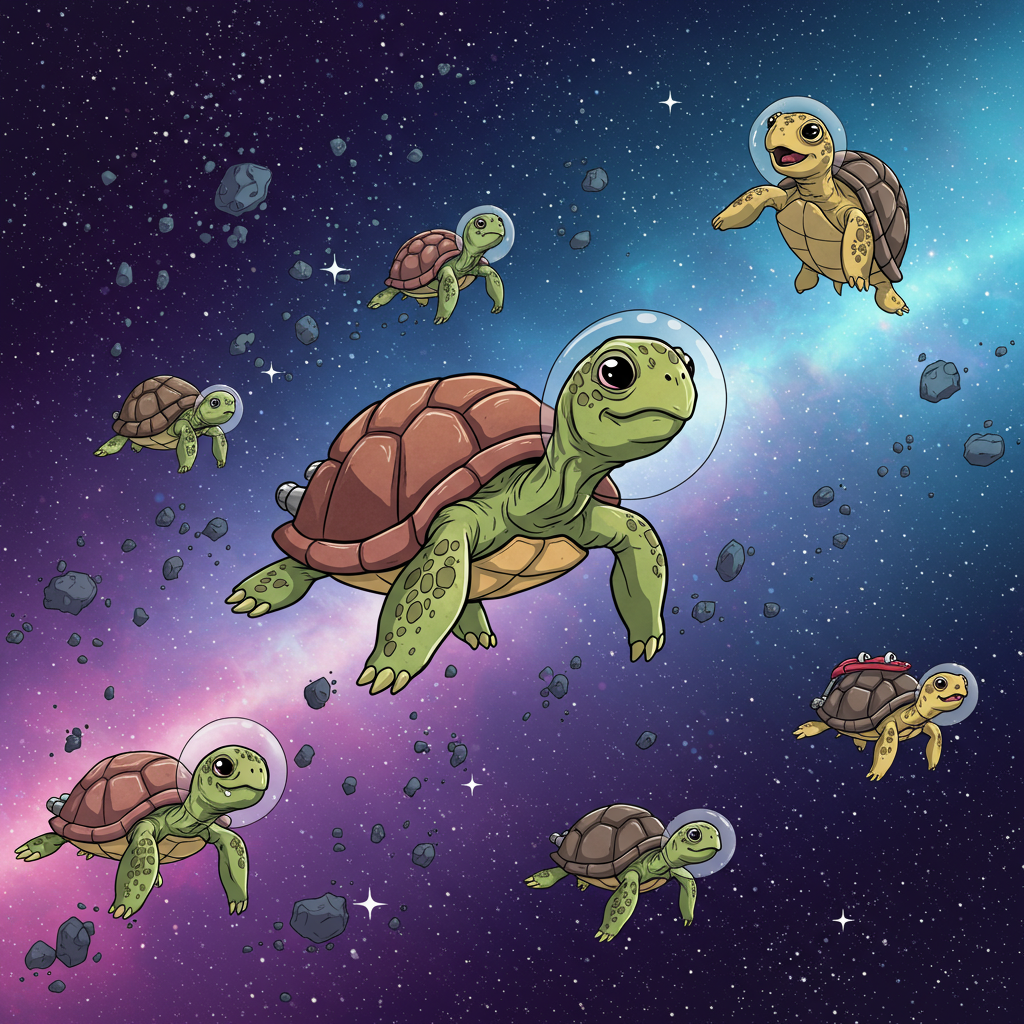

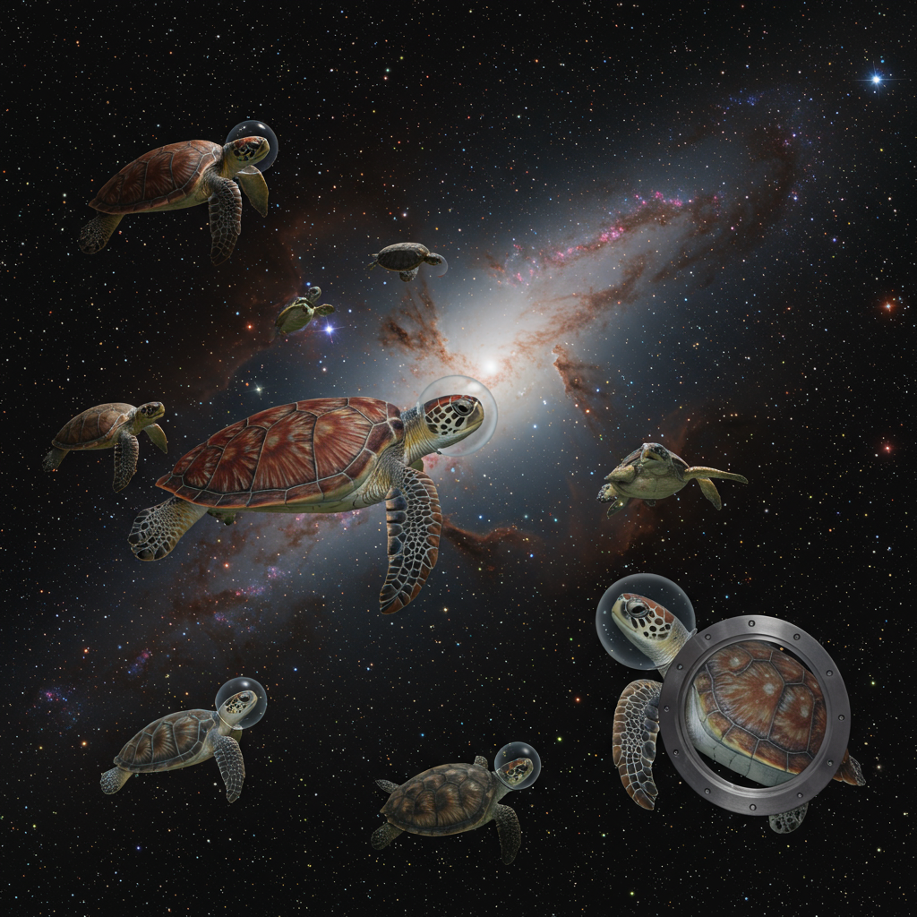

- `generated_images`:

  **generated_images[0]**

  - `image`:

    - `image_bytes`: b’89PNG1a…’

    - `mime_type`: image/png

  **generated_images[1]**

  - `image`:

    - `image_bytes`: b’89PNG1a…’

    - `mime_type`: image/png

```python
mr
```

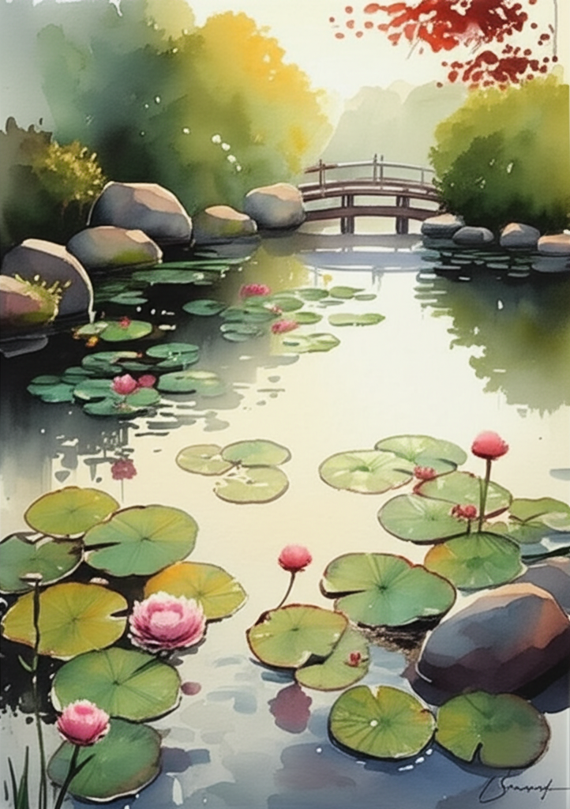

Still water so calm,  
Lily pads like floating dreams,  
Peace the only sound.

- `usage_metadata`: Cached: 0; In: 16; Out: 18; Total: 34

- `model_version`: gemini-2.0-flash-exp

- `automatic_function_calling_history`:

- `candidates`:

  **candidates[0]**

  - `finish_reason`: FinishReason.STOP

  - `content`:

    - `parts`:

      **parts[0]**

      - `inline_data`:

        - `data`: b’89PNG1a…’

        - `mime_type`: image/png

      **parts[1]**

      - `text`:

        Still water so calm, Lily pads like floating dreams, Peace the only sound.

    - `role`: model

  - `index`: 0

```python
mmr
```